# Inferencia estadística V

Inferencia bayesiana

Autor/a

Alejandro Veloz

Este apunte sigue el capítulo 11 de Wasserman y cierra la unidad. Los métodos de los apuntes I a IV son **frecuentistas**. El enfoque bayesiano responde a preguntas distintas con herramientas distintas, y conviene entender ambos para saber cuál corresponde a cada problema.

# 1 Las dos filosofías

El punto de vista frecuentista descansa en tres postulados. La probabilidad se refiere a frecuencias relativas límite y es una propiedad objetiva del mundo. Los parámetros son constantes fijas y desconocidas, de modo que no tiene sentido hacer afirmaciones de probabilidad sobre ellos. Y los procedimientos se diseñan para tener propiedades de largo plazo bien definidas, como un intervalo que atrapa al parámetro el 95 % de las veces.

El punto de vista bayesiano descansa en otros tres. La probabilidad describe grado de creencia, no frecuencia límite, de modo que se pueden hacer afirmaciones de probabilidad sobre muchas cosas y no sólo sobre datos sujetos a variación aleatoria. Se pueden hacer afirmaciones de probabilidad sobre parámetros, aunque sean constantes. Y la inferencia sobre $\theta$ consiste en producir una distribución de probabilidad para $\theta$, de la cual se extraen estimaciones puntuales y por intervalo.

La inferencia bayesiana es controvertida porque incorpora una noción subjetiva de probabilidad y, en general, no ofrece garantías de comportamiento en el largo plazo. La estadística pone más énfasis en los métodos frecuentistas; ciertas comunidades de aprendizaje automático adoptan los bayesianos con fuerza. Dejemos por ahora la discusión filosófica y veamos cómo se hace.

# 2 El método bayesiano

1. Se elige una densidad $f(\theta)$, la **distribución a priori** (*prior*), que expresa las creencias sobre $\theta$ antes de ver los datos.
2. Se elige un modelo $f(x \mid \theta)$, que ahora se escribe con barra condicional y no con punto y coma.
3. Tras observar $X_1, \ldots, X_n$, se actualizan las creencias calculando la **distribución a posteriori** $f(\theta \mid X_1, \ldots, X_n)$.

El tercer paso es el teorema de Bayes. Con $X^n = (X_1, \ldots, X_n)$ y $f(x^n \mid \theta) = \prod_i f(x_i \mid \theta) = \mathcal{L}_n(\theta)$,
$$f(\theta \mid x^n) = \frac{f(x^n \mid \theta)\,f(\theta)}{\int f(x^n \mid \theta)\,f(\theta)\,d\theta} = \frac{\mathcal{L}_n(\theta)\,f(\theta)}{c_n} \propto \mathcal{L}_n(\theta)\,f(\theta),$$
donde $c_n = \int \mathcal{L}_n(\theta) f(\theta)\,d\theta$ es la **constante de normalización**, que no depende de $\theta$. En palabras, la posterior es proporcional a la verosimilitud por la prior. La constante se descarta durante el cálculo y se recupera al final si hace falta.

De la posterior se extrae una estimación puntual, normalmente la **media posterior**
$$\bar\theta_n = \int \theta\, f(\theta \mid x^n)\,d\theta = \frac{\int \theta\,\mathcal{L}_n(\theta) f(\theta)\,d\theta}{\int \mathcal{L}_n(\theta) f(\theta)\,d\theta},$$
o la moda, y un **intervalo posterior** $C = (a, b)$ con $\int_{-\infty}^a f(\theta \mid x^n)\,d\theta = \int_b^\infty f(\theta \mid x^n)\,d\theta = \alpha/2$, que satisface $\mathbb{P}(\theta \in C \mid x^n) = 1 - \alpha$. A diferencia del intervalo de confianza, éste sí es una afirmación de probabilidad sobre $\theta$, en el sentido de grado de creencia.

## 2.1 Bernoulli con prior Beta

Sea $X_1, \ldots, X_n \sim \text{Bernoulli}(p)$ con prior uniforme $f(p) = 1$. La posterior es
$$f(p \mid x^n) \propto p^s(1-p)^{n-s} = p^{(s+1)-1}(1-p)^{(n-s+1)-1},$$
con $s = \sum_i x_i$. Se reconoce una distribución Beta, cuya densidad es $f(p;\alpha,\beta) = \frac{\Gamma(\alpha+\beta)}{\Gamma(\alpha)\Gamma(\beta)}p^{\alpha-1}(1-p)^{\beta-1}$. Luego $p \mid x^n \sim \text{Beta}(s+1, n-s+1)$, y la constante de normalización quedó determinada sin integrar. La media de una Beta$(\alpha,\beta)$ es $\alpha/(\alpha+\beta)$, de modo que el estimador de Bayes es
$$\bar p = \frac{s+1}{n+2} = \lambda_n\,\hat p + (1 - \lambda_n)\,\tfrac12, \qquad \lambda_n = \frac{n}{n+2},$$
una combinación convexa del EMV $\hat p = s/n$ y la media de la prior. Con $n$ grande, $\lambda_n \approx 1$ y la prior deja de importar.

Con prior $p \sim \text{Beta}(\alpha, \beta)$ en lugar de uniforme, la posterior es $\text{Beta}(\alpha + s, \beta + n - s)$, con media
$$\bar p = \frac{\alpha + s}{\alpha + \beta + n} = \frac{n}{\alpha+\beta+n}\,\hat p + \frac{\alpha+\beta}{\alpha+\beta+n}\,p_0,$$
donde $p_0 = \alpha/(\alpha+\beta)$ es la media de la prior. La prior actúa como $\alpha + \beta$ observaciones ficticias con proporción $p_0$. Cuando prior y posterior pertenecen a la misma familia, la prior se llama **conjugada**.

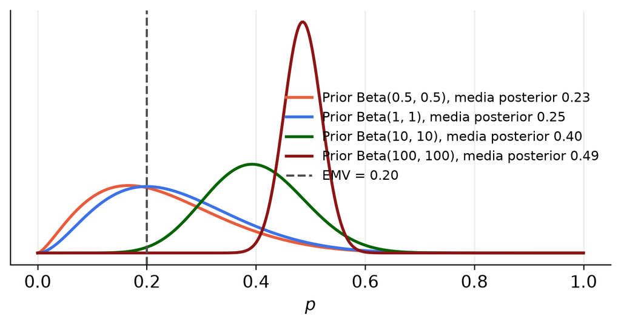

Posterior de p para diez lanzamientos con dos éxitos, bajo cuatro priors Beta. Con priors informativas la posterior se desplaza hacia la media de la prior; con más datos la diferencia se diluye.

```python
x = np.array([0, 1, 0, 1, 0, 0, 0, 0, 0, 0]); s, n = x.sum(), len(x)
pg = np.linspace(0, 1, 400)
fig, ax = plt.subplots(figsize=(7.5, 3.2))
for (a, b), c in zip([(0.5, 0.5), (1, 1), (10, 10), (100, 100)], [MYORANGE, MYBLUE, MYGREEN, MYRED]):
    post = stats.beta(a + s, b + n - s)
    ax.plot(pg, post.pdf(pg), color=c, lw=2, label="Prior Beta(%g, %g), media posterior %.2f" % (a, b, post.mean()))
ax.axvline(s/n, color=GRAY, ls="--", label="EMV = %.2f" % (s/n))
ax.set_xlabel("$p$"); ax.set_yticks([]); ax.legend(fontsize=9); plt.show()
```

```python
def posterior_bernoulli(x, a=1.0, b=1.0, alpha=0.05):
    s, n = np.sum(x), len(x)
    post = stats.beta(a + s, b + n - s)
    return dict(media=post.mean(), intervalo=post.ppf([alpha/2, 1 - alpha/2]), emv=s/n)

print({k: np.round(v, 3) for k, v in posterior_bernoulli(x).items()})
```

```
{'media': np.float64(0.25), 'intervalo': array([0.06 , 0.518]), 'emv': np.float64(0.2)}
```

## 2.2 Normal con prior normal

Sea $X_1, \ldots, X_n \sim N(\theta, \sigma^2)$ con $\sigma$ conocida y prior $\theta \sim N(a, b^2)$. La posterior es $\theta \mid X^n \sim N(\bar\theta, \tau^2)$ con
$$\bar\theta = w\bar X + (1 - w)a, \qquad w = \frac{1/\operatorname{se}^2}{1/\operatorname{se}^2 + 1/b^2}, \qquad \frac{1}{\tau^2} = \frac{1}{\operatorname{se}^2} + \frac{1}{b^2},$$
y $\operatorname{se} = \sigma/\sqrt n$. Las precisiones (inversos de varianzas) se suman, y la media posterior pondera la media muestral y la media de la prior por sus precisiones. Cuando $n \to \infty$, $w \to 1$ y $\tau/\operatorname{se} \to 1$, de modo que la posterior es aproximadamente $N(\hat\theta, \operatorname{se}^2)$. Lo mismo ocurre con $n$ fijo si $b \to \infty$, es decir, si la prior se vuelve plana. El intervalo posterior del 95 % es $\bar\theta \pm 1{,}96\tau$, que para $n$ grande coincide con el intervalo de confianza frecuentista $\hat\theta \pm 1{,}96\operatorname{se}$.

```python
def posterior_normal(x, sigma, a=0.0, b=10.0):
    n = len(x); se2 = sigma**2 / n
    prec = 1/se2 + 1/b**2
    media = (x.mean()/se2 + a/b**2) / prec
    return media, np.sqrt(1/prec)

x = rng.normal(2.0, 1.0, 25)
for b in [0.5, 2.0, 100.0]:
    m, t = posterior_normal(x, 1.0, a=0.0, b=b)
    print("prior N(0, %5.1f^2):  media posterior = %.3f   sd posterior = %.3f   (media muestral = %.3f, se = %.3f)" % (b, m, t, x.mean(), 1/np.sqrt(len(x))))
```

```
prior N(0,   0.5^2):  media posterior = 2.009   sd posterior = 0.186   (media muestral = 2.331, se = 0.200)
prior N(0,   2.0^2):  media posterior = 2.308   sd posterior = 0.199   (media muestral = 2.331, se = 0.200)
prior N(0, 100.0^2):  media posterior = 2.331   sd posterior = 0.200   (media muestral = 2.331, se = 0.200)
```

# 3 Funciones del parámetro y simulación

Para inferir sobre $\tau = g(\theta)$ se calcula la distribución de una transformación, como en el capítulo de variables aleatorias. La posterior de $\tau$ tiene función de distribución $H(\tau \mid x^n) = \mathbb{P}(g(\theta) \le \tau \mid x^n)$. Con $p \mid x^n \sim \text{Beta}(s+1, n-s+1)$ y $\psi = \log(p/(1-p))$ el cálculo analítico es posible pero engorroso.

La **simulación** evita todo cálculo. Si se extraen $\theta_1, \ldots, \theta_B \sim f(\theta \mid x^n)$, un histograma de esos valores aproxima la posterior, su promedio aproxima la media posterior, sus cuantiles $\alpha/2$ y $1 - \alpha/2$ aproximan el intervalo posterior, y $\tau_i = g(\theta_i)$ es una muestra de la posterior de $\tau$. Para el log-odds basta con extraer $P_1, \ldots, P_B$ de la Beta y calcular $\psi_i = \log(P_i/(1 - P_i))$.

```
media posterior de psi = -0.826   intervalo 95 % = (-1.520, -0.184)
```

[figure not shown]

```python
s, n = 12, 40
P = rng.beta(s + 1, n - s + 1, 20_000); psi = np.log(P/(1 - P))
print("media posterior de psi = %.3f   intervalo 95 %% = (%.3f, %.3f)" % (psi.mean(), *np.quantile(psi, [.025, .975])))
from scipy.special import gammaln
def h_psi(ps):
    e = np.exp(ps)/(1 + np.exp(ps))
    return np.exp(gammaln(n+2) - gammaln(s+1) - gammaln(n-s+1)) * e**s * (1 - e)**(n - s + 2)
fig, ax = plt.subplots(figsize=(7, 2.8))
ax.hist(psi, bins=50, density=True, color=MYBLUE, alpha=.7); g = np.linspace(-2.5, 1, 300); ax.plot(g, h_psi(g), color=MYRED, lw=2)
ax.set_xlabel("$\\psi = \\log(p/(1-p))$"); ax.set_yticks([]); plt.show()
```

# 4 Propiedades con muestras grandes

En los ejemplos anteriores la media posterior estaba cerca del EMV, y esto vale en general.

**Teorema.** Sea $\hat\theta_n$ el EMV y $\widehat{\operatorname{se}} = 1/\sqrt{nI(\hat\theta_n)}$. Bajo condiciones de regularidad, la posterior es aproximadamente normal con media $\hat\theta_n$ y desviación $\widehat{\operatorname{se}}$. En consecuencia $\bar\theta_n \approx \hat\theta_n$, y el intervalo de confianza frecuentista $\hat\theta_n \pm z_{\alpha/2}\widehat{\operatorname{se}}$ es también un intervalo posterior aproximado de nivel $1-\alpha$.

La demostración expande $\log f(\theta \mid X^n) \approx \ell(\theta)$ en torno a $\hat\theta$ hasta segundo orden; el término lineal se anula porque $\ell'(\hat\theta) = 0$ y el cuadrático da una normal con varianza $-1/\ell''(\hat\theta) \approx 1/(nI(\hat\theta))$. Hay también un método delta bayesiano, $\tau \mid X^n \approx N(g(\hat\theta), \widehat{\operatorname{se}}^2 g'(\hat\theta)^2)$. En modelos paramétricos con muestras grandes, los dos enfoques dan aproximadamente las mismas inferencias. En general no tienen por qué coincidir.

# 5 Priors planas, impropias y no informativas

¿De dónde sale la prior? La escuela subjetivista sostiene que debe reflejar la opinión previa sobre $\theta$. Esto puede ser posible en algunos casos, pero es impracticable en problemas complicados con muchos parámetros, y va contra el objetivo de hacer la inferencia científica tan objetiva como sea posible. La alternativa es buscar una prior “no informativa”, y el candidato obvio es la prior plana $f(\theta) \propto$ constante. Su uso sin restricciones plantea dos cuestiones.

**Priors impropias.** Con $X \sim N(\theta, \sigma^2)$ y $f(\theta) \propto c$, se tiene $\int f(\theta)\,d\theta = \infty$ y la prior no es una densidad. Aun así el teorema de Bayes se puede aplicar formalmente y da $\theta \mid X^n \sim N(\bar X, \sigma^2/n)$, cuyos estimadores puntual y por intervalo coinciden exactamente con los frecuentistas. Las priors impropias no son un problema mientras la posterior resultante sea una distribución de probabilidad bien definida.

**Las priors planas no son invariantes.** Con $X \sim \text{Bernoulli}(p)$ y prior plana $f(p) = 1$, la prior inducida sobre $\psi = \log(p/(1-p))$ es $f_\Psi(\psi) = e^\psi/(1 + e^\psi)^2$, que no es plana. Si somos ignorantes sobre $p$ también lo somos sobre $\psi$ y deberíamos usar una prior plana para $\psi$, lo que es una contradicción. La noción de prior plana no está bien definida porque depende de la parametrización.

**Prior de Jeffreys.** La regla de Jeffreys, $f(\theta) \propto I(\theta)^{1/2}$ con $I$ la información de Fisher, es invariante ante reparametrizaciones. Para Bernoulli, $I(p) = 1/(p(1-p))$ y la prior es $\propto p^{-1/2}(1-p)^{-1/2}$, una Beta$(1/2, 1/2)$, muy cercana a la uniforme. En varios parámetros se usa $\sqrt{|I(\theta)|}$.

# 6 Problemas con varios parámetros

Con $\theta = (\theta_1, \ldots, \theta_p)$ la posterior sigue siendo $f(\theta \mid x^n) \propto \mathcal{L}_n(\theta) f(\theta)$. Para inferir sobre $\theta_1$ se necesita la **posterior marginal** $f(\theta_1 \mid x^n) = \int\cdots\int f(\theta \mid x^n)\,d\theta_2\cdots d\theta_p$, integral que rara vez es factible. La simulación resuelve el problema: se extraen vectores $\theta^1, \ldots, \theta^B$ de la posterior conjunta y se recogen las primeras componentes, que son una muestra de la marginal.

**Comparación de dos binomiales.** Con $n_1$ controles y $n_2$ tratados, $X_1$ y $X_2$ éxitos y $\tau = p_2 - p_1$. Con prior $f(p_1, p_2) = 1$, la posterior factoriza, $p_1$ y $p_2$ son independientes a posteriori con $p_j \mid x_j \sim \text{Beta}(x_j + 1, n_j - x_j + 1)$. Simulando $P_{1,b}$ y $P_{2,b}$ de cada Beta, $\tau_b = P_{2,b} - P_{1,b}$ es una muestra de la posterior de $\tau$.

```
media posterior = 0.060   intervalo 95 % = (0.003, 0.117)   P(tau > 0 | datos) = 0.979
```

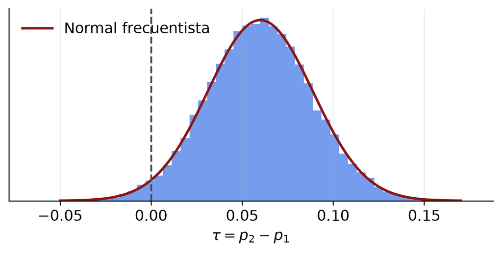

Posterior de la diferencia de proporciones de uso frecuente entre dos macrozonas, obtenida por simulación, con la aproximación normal frecuentista superpuesta.

```python
x1, n1, x2, n2 = 276, 600, 312, 600
tau = rng.beta(x2 + 1, n2 - x2 + 1, 20_000) - rng.beta(x1 + 1, n1 - x1 + 1, 20_000)
print("media posterior = %.3f   intervalo 95 %% = (%.3f, %.3f)   P(tau > 0 | datos) = %.3f" % (tau.mean(), *np.quantile(tau, [.025, .975]), np.mean(tau > 0)))
d = x2/n2 - x1/n1; se = np.sqrt((x1/n1)*(1-x1/n1)/n1 + (x2/n2)*(1-x2/n2)/n2)
fig, ax = plt.subplots(figsize=(7, 2.8))
ax.hist(tau, bins=50, density=True, color=MYBLUE, alpha=.7); g = np.linspace(-0.05, 0.17, 300); ax.plot(g, stats.norm.pdf(g, d, se), color=MYRED, lw=2, label="Normal frecuentista")
ax.axvline(0, color=GRAY, ls="--"); ax.set_xlabel("$\\tau = p_2 - p_1$"); ax.set_yticks([]); ax.legend(); plt.show()
```

La cantidad $\mathbb{P}(\tau > 0 \mid \text{datos})$ es lo que muchos usuarios creen estar leyendo cuando ven un valor $p$. Sólo el enfoque bayesiano la produce, y a cambio depende de la prior.

# 7 Contraste bayesiano

El contraste de hipótesis bayesiano es un tema complejo, y aquí se da sólo la idea. Se pone una prior sobre $H_0$ y sobre $\theta$ y se calcula $\mathbb{P}(H_0 \mid X^n)$. Para $H_0 : \theta = \theta_0$ contra $H_1 : \theta \ne \theta_0$ con $\mathbb{P}(H_0) = \mathbb{P}(H_1) = 1/2$ y prior $f(\theta)$ bajo $H_1$,
$$\mathbb{P}(H_0 \mid x^n) = \frac{\mathcal{L}(\theta_0)}{\mathcal{L}(\theta_0) + \int\mathcal{L}(\theta) f(\theta)\,d\theta}.$$
En estimación la prior influía poco y los dos enfoques coincidían; en contraste no es así. No se pueden usar priors impropias, porque la integral del denominador queda indefinida, y la prior $f(\theta)$ debe elegirse con cuidado. Existe una cota que no depende de la prior: como $\int\mathcal{L}(\theta)f(\theta)\,d\theta \le \mathcal{L}(\hat\theta)$,
$$\mathbb{P}(H_0 \mid x^n) \ge \frac{\mathcal{L}(\theta_0)}{\mathcal{L}(\theta_0) + \mathcal{L}(\hat\theta)}.$$

El siguiente cálculo compara $\mathbb{P}(H_0 \mid x)$ con el valor $p$ para una media normal. La probabilidad posterior de $H_0$ puede ser grande aunque el valor $p$ sea pequeño, sobre todo con $n$ grande. Este desacuerdo se conoce como **paradoja de Jeffreys y Lindley**, y es la razón más concreta por la que el valor $p$ no debe leerse como probabilidad de la nula.

```python
def prob_H0(xbar, n, b=1.0, sigma=1.0):
    """P(H0 | datos) para H0: mu = 0 contra mu ~ N(0, b^2), sigma conocida, prior 1/2 en cada hipótesis."""
    L0 = stats.norm.pdf(xbar, 0, sigma/np.sqrt(n))
    L1 = stats.norm.pdf(xbar, 0, np.sqrt(sigma**2/n + b**2))   # verosimilitud marginal bajo H1
    return L0 / (L0 + L1)

for n in [10, 100, 1000, 10_000]:
    xbar = 1.96 / np.sqrt(n)                                    # datos con valor p = 0,05 exactamente
    print("n = %6d   valor p = 0,050   P(H0 | datos) = %.3f" % (n, prob_H0(xbar, n)))
```

```
n =     10   valor p = 0,050   P(H0 | datos) = 0.367
n =    100   valor p = 0,050   P(H0 | datos) = 0.600
n =   1000   valor p = 0,050   P(H0 | datos) = 0.823
n =  10000   valor p = 0,050   P(H0 | datos) = 0.936
```

# 8 Fortalezas y debilidades

La inferencia bayesiana es atractiva cuando hay información previa, porque el teorema de Bayes es la manera natural de combinarla con los datos, y porque permite afirmaciones de probabilidad sobre parámetros, mientras que el enfoque frecuentista sólo permite afirmaciones sobre el intervalo $C_n$ y no sobre $\theta$. El atractivo psicológico no es un argumento científico para preferir un tipo de inferencia. En modelos paramétricos con muestras grandes ambos enfoques coinciden aproximadamente. En general no.

Tres ejemplos ilustran las fortalezas y las debilidades. En el ejemplo de Berger y Wolpert del apunte I, con $Y_1 = 15$ e $Y_2 = 17$, la verosimilitud vale $1/4$ en $\theta = 16$ y cero en el resto, de modo que con cualquier prior positiva la posterior es $\mathbb{P}(\theta = 16 \mid Y) = 1$. El intervalo de confianza del 75 % era $\{16\}$; la posterior dice lo que uno quería decir. Aquí el enfoque bayesiano es más satisfactorio.

El ejemplo de Robins y Ritov muestra el caso contrario. Se observan tripletas $(X_i, R_i, Y_i)$ donde $X_i$ es uniforme en $\{1, \ldots, B\}$ con $B$ enorme, $R_i \sim \text{Bernoulli}(\xi_{X_i})$ con $\xi$ conocidas, e $Y_i \sim \text{Bernoulli}(\theta_{X_i})$ se observa sólo si $R_i = 1$. Es una caricatura de datos faltantes. Se quiere $\psi = \mathbb{P}(Y_i = 1) = B^{-1}\sum_j\theta_j$. La verosimilitud depende de $\theta$ sólo a través de los $\theta_j$ con $X_i = j$ para algún $i$, y como $B \gg n$, casi todos los $\theta_j$ no aparecen en la verosimilitud, de modo que su posterior es igual a su prior y $f(\psi \mid \text{datos}) \approx f(\psi)$. Los datos no informan sobre $\psi$ en un análisis bayesiano. El estimador frecuentista de Horvitz y Thompson, $\hat\psi = n^{-1}\sum_i R_iY_i/\xi_{X_i}$, es insesgado con varianza a lo más $1/(n\delta^2)$, de modo que su ECM va a cero como $1/n$ sin importar $B$. Ese estimador usa las $\xi$, que se cancelan de la verosimilitud y no aparecen en ningún método basado en ella. Los métodos bayesianos están atados a la verosimilitud, y en problemas de alta dimensión o no paramétricos la verosimilitud puede no dar inferencias precisas. Este ejemplo es la razón por la que los estimadores de encuestas con ponderadores, como los de la tarea, son frecuentistas.

En el tercer ejemplo, $f(x) = c\,g(x)$ con $g$ conocida y $c$ la constante de normalización desconocida. La verosimilitud es $\prod_i c\,g(X_i) \propto c^n$, la posterior es $\propto c^n\pi(c)$ y no depende de los datos: desde el punto de vista bayesiano los datos no informan sobre $c$, y la media posterior tiende a infinito con $n$. Un estimador frecuentista consistente es inmediato, $\hat c = \hat f(x)/g(x)$ con $\hat f$ un estimador de densidad.

La conclusión es que los dos enfoques responden preguntas distintas. Para combinar creencias previas con datos de manera basada en principios, se usa la inferencia bayesiana. Para construir procedimientos con garantías de largo plazo, como intervalos de confianza, se usan los métodos frecuentistas. Los métodos bayesianos tienen problemas cuando el espacio de parámetros es de alta dimensión, y en particular los intervalos posteriores del 95 % no tienen por qué contener al valor verdadero el 95 % de las veces.

# 9 Síntesis esquemática

La inferencia bayesiana trata a $\theta$ como variable aleatoria, parte de una prior y la actualiza con la verosimilitud mediante el teorema de Bayes; la posterior es proporcional a verosimilitud por prior. Con priors conjugadas (Beta para Bernoulli, normal para la media normal) la posterior tiene forma cerrada y su media es una combinación convexa del EMV y la media de la prior, con peso creciente en los datos. La simulación desde la posterior sustituye a toda integral, incluidas las de funciones del parámetro y las marginales. Con muestras grandes la posterior es aproximadamente normal centrada en el EMV y coincide con la inferencia frecuentista. Las priors planas dependen de la parametrización; la de Jeffreys no. En contraste de hipótesis la prior sí importa y $\mathbb{P}(H_0 \mid \text{datos})$ puede ser grande con valor $p$ pequeño. Los métodos bayesianos dependen enteramente de la verosimilitud y fallan cuando ésta no captura la información, como en el ejemplo de Robins y Ritov; los frecuentistas ofrecen garantías de largo plazo que los bayesianos no.